[O’Hara on GitHub](https://github.com/oharac)

# Test raster resolution options for IUCN maps

Compiled on Thu May 31 09:10:44 2018 by ohara

```r
knitr::opts_chunk$set(fig.width = 6, fig.height = 4, fig.path = 'Figs/',
                      echo = TRUE, message = FALSE, warning = FALSE)

library(raster)
source('https://raw.githubusercontent.com/oharac/src/master/R/common.R')

library(sf)

dir_git <- '~/github/spp_health_dists'
dir_o_anx <- file.path(dir_O, 'git-annex/spp_health_dists')

### goal specific folders and info
dir_check   <- file.path(dir_git, 'data/iucn/map_check')

dir_shp <- file.path(dir_M, 'git-annex/globalprep/_raw_data/iucn_spp/d2017-3')
```

# 1 Summary

Using a set of IUCN species range maps, test several options for rasterization. If we can get most maps via IUCN then we are not tied to AquaMaps half-degree cell resolution. The concern, however, is file size and convenience. As well, the finer resolution is only valuable to a point - since it is still just presence/absence on a polygon, that resolution only matters on the boundaries.

Options to examine, both in raster format and dataframe/csv format:

- half degree cells, using AquaMaps/LOICZID cells as baseline
- finer resolutions in lat-long: e.g. .25 degree or .10 degree; these would allow the new data to play well with AquaMaps.
- equal area projection e.g. cylindrical equal area projection or Mollweide. These would require a transformation step. Mollweide reprojection can have issues with polygons on the +/- 180 degree line, creating artifacts that streak horizontally across the globe. Cylindrical seems less likely to have this issue, though then does not play well with Cumulative Human Impact-style data.

Likely solution: quarter degree (or smaller) remaining in lat-long to avoid reprojection. Aggregated maps can be reprojected to CHI projection/resolution afterward for subsequent analysis.

# 2 Methods

Select several IUCN shapefile collections of maps for species with a variety of ranges. First, examine the mean ranges, variance, and number of species by using the shape area from the dbfs.

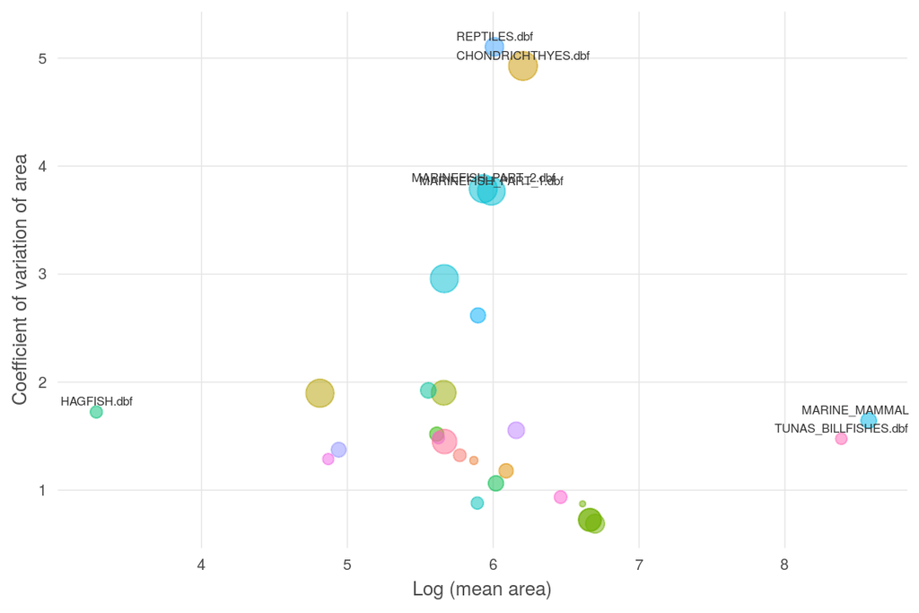

```r
dbfs <- list.files(dir_shp, pattern = '\\.dbf$', full.names = TRUE)

marine_spp <- read_csv(file.path(dir_git, 'data/iucn/spp_marine_from_api_2017-3.csv'))

area_df <- lapply(dbfs, foreign::read.dbf) %>%
  setNames(basename(dbfs)) %>%
  bind_rows(.id = 'dbf_file') %>%
  select(dbf_file, iucn_sid = id_no, sciname = binomial, code, presence, subpop, shape_Area) %>%
  filter(iucn_sid %in% marine_spp$iucn_sid)

write_csv(area_df, file.path(dir_check, 'poly_areas.csv'))
area_gp_df <- area_df %>%
  group_by(dbf_file) %>%
  summarize(mean_area = mean(shape_Area, na.rm = TRUE),
            var_area = var(shape_Area, na.rm = TRUE),
            coef_area = sqrt(var_area) / mean_area,
            n_spp = n()) %>%
  mutate(group = tolower(dbf_file) %>% str_replace_all('_part.+|\\.dbf', ''),
         log_mean = log(mean_area),
         label = ifelse(log_mean > 8 | log_mean < 4 | coef_area > 3.5, dbf_file, NA))

ggplot(area_gp_df, aes(x = log_mean, y = coef_area, color = group, size = n_spp)) +
  ggtheme_plot() +
  geom_point(alpha = .5, show.legend = FALSE) +
  geom_text(aes(label = label), size = 2, color = 'grey20', nudge_y = .1) +
  labs(x = 'Log (mean area)',
       y = 'Coefficient of variation of area')
```

Seems like marine mammals represent large-ranged critters, so may represent the largest of rasters; chondrichthyes seem to represent highly variable critters in terms of range, so will provide a good range of raster sizes for comparison. Let’s also include Marine Fishes for fun.

## 2.1 Process at half-degree cells

Retrieve AquaMaps LOICZID raster and sequentially rasterize each species map in the collection as well as performing raster::extract on the map set. Time both methods for comparison.

### 2.1.1 Rasterize with `fasterize()`

We will loop over each species in each shapefile and rasterize separately, using `sf` and `fasterize` packages.

```r
shp_files_all <- list.files(dir_shp, pattern = '\\.shp$', full.names = TRUE)
shp_info  <- file.info(shp_files_all) %>%
  mutate(shp = shp_files_all)

keepers <- c('CHOND', 'MAMM', 'MARINEFISH_PART_1') %>% paste0(collapse = '|')

shp_files <- shp_info %>%
  filter(size < 200e6 | str_detect(shp, keepers)) %>%
  .$shp

verbose <- FALSE

dir_rast <- file.path(dir_o_anx, 'rasters')

rast_base <- raster::raster(file.path(dir_git, 'spatial/loiczid_raster.tif'))

spp_vs_time_df <- data.frame()

for(shp in shp_files) { ### shp <- shp_files[1]
  ptm_shp <- proc.time()
  if(verbose) cat('Processing', basename(shp), '...\n')
  shp_sf <- st_read(shp)
  if(verbose) cat('  Time to read shp:', (proc.time() - ptm_shp)[3], 's...\n')

  for(id in shp_sf$id_no) { ### id <- shp_sf$id_no[1]
    spp_shp <- shp_sf %>%
      filter(id_no == id)

    rast_file <- file.path(dir_o_anx, sprintf('rasters/iucn_sid_%s_050deg.tif', id))
    # if(verbose) cat('  Rasterizing', id, ':', spp_shp$binomial, 'to: ', basename(rast_file), '...\n')

    spp_rast <- fasterize::fasterize(spp_shp, rast_base, field = 'presence', fun = 'min')


    raster::writeRaster(spp_rast, rast_file, overwrite = TRUE)
  }

  if(verbose) cat('  Elapsed time for', nrow(shp_sf), 'species:', (proc.time() - ptm_shp)[3], 's...\n')

  tmp_df <- data.frame('group' = basename(shp),
                       'n_spp' = nrow(shp_sf),
                       'time'  = (proc.time() - ptm_shp)[3])
  spp_vs_time_df <- spp_vs_time_df %>%
    bind_rows(tmp_df)

}

write_csv(spp_vs_time_df, file.path(dir_check, 'spp_time_to_rast_050deg.csv'))
```

### 2.1.2 Extract with `raster::extract()`

From v2017 and earlier Species goal data prep.

```r
cache_dir <- (file.path(dir_o_anx, 'rasters'))

extract_from_shp <- function(shp, cache_dir, rast,
                             fn_tag   = NULL,
                             reload   = FALSE) {
  ### will extract a shapefile to a raster, and save the .csv as a
  ### file in cache_dir with a matching name (e.g. BOTW.shp -> BOTW.csv).
  ### NOTE: any filtering of shapefiles should be done before passing them
  ### to this function; e.g. filter TERRESTRIAL_MAMMALS.shp to just those
  ### that occur in marine habitats.
  ### * shp must include .shp extension and must include full path name.

  if(!file.exists(shp)) {
    message('Shapefile ', shp, ' does not exist.  shp argument must contain ',
            'the full path name, including .shp extension.')

    return(data.frame(msg = 'pathname error'))
  }

  ### determine species group (the shapefile base name without extension)
  spp_gp <- basename(shp) %>% str_replace('.shp', '')

  cache_file <- file.path(cache_dir,
                          paste0(spp_gp,
                                 ifelse(is.null(fn_tag), '', fn_tag),
                                 '.csv'))

  ### if reload == FALSE, and the file exists, don't waste your friggin' time here, move on to next group.
  if(file.exists(cache_file) & reload == FALSE) {
    message(sprintf('IUCN <-< LOICZID lookup file already exists for species group %s;',
                    ' file location:\n  %s', spp_gp, cache_file))
    return(data.frame(msg = paste(cache_file, ' already exists, not reprocessed')))
  } else {
    ptm <- proc.time()
    fsize <- round(file.size(shp)/1e6, 2)
    message(sprintf('Reading species group shapefile %s, %.2f MB\n  %s', spp_gp, fsize, shp))

    ### Because the IUCN metadata states that shapefiles are unprojected lat-long with WGS84,
    ### use readShapePoly (rather than readOGR) and manually tell it the projection...
    spp_shp <- maptools::readShapePoly(fn = shp,
                                       proj4string = CRS('+init=epsg:4326'),
                                       delete_null_obj = TRUE)
    # spp_shp <- rgdal::readOGR(dsn = dirname(shp),
    #                           layer = basename(shp) %>% str_replace('.shp', ''),
    #                           stringsAsFactors = FALSE)
    message(sprintf('Elapsed read time: %.2f seconds', (proc.time() - ptm)[3]))

    message(sprintf('... processing %s species',
                    length(unique(spp_shp@data$id_no))))

    message('Extracting polygons to LOICZID cells...')
    ptm <- proc.time()
    spp_shp_prop <- raster::extract(rast, spp_shp,
                                    weights = TRUE, normalizeWeights = FALSE,
                                    progress = 'text')
    message(sprintf('Elapsed process time: %.2f minutes', (proc.time() - ptm)[3]/60))


    ### combine sciname, iucn_sid, presence, and subpop code for a single unique identifier
    shp_id <- data.frame('sciname'  = spp_shp@data$binomial,
                         'iucn_sid' = spp_shp@data$id_no,
                         'presence' = spp_shp@data$presence,
                         'subpop'   = spp_shp@data$subpop) %>%
      unite(name_id, sciname, iucn_sid, presence, subpop, sep = '_')

    names(spp_shp_prop) <- shp_id$name_id

    ### convert list to data frame.
    spp_shp_prop_df <- plyr::ldply(spp_shp_prop, rbind)
    spp_shp_prop_df <- spp_shp_prop_df %>%
      rename(name_id   = .id,
             LOICZID   = value,
             prop_area = weight) %>%
      separate(name_id, c('sciname', 'iucn_sid', 'presence', 'subpop'), sep = '_') %>%
      distinct()

    ### save .csv for this species group
    message(sprintf('%s: %s species maps, %s total cells in output file',
                    spp_gp, length(unique(spp_shp_prop_df$iucn_sid)),
                    nrow(spp_shp_prop_df)))
    message(sprintf('Writing IUCN<->LOICZID intersection file for %s to:\n  %s', spp_gp, cache_file))
    write_csv(spp_shp_prop_df, cache_file)
  }

  return(invisible(spp_shp_prop_df))
}
```

```r
verbose <- TRUE

spp_vs_time_df <- data.frame()

for(shp in shp_files) { ### shp <- shp_files[3]
  ptm_shp <- proc.time()
  if(verbose) cat('Processing', basename(shp), '...\n')

  if(!file.exists(sprintf('%s/%s.csv', cache_dir, str_replace(basename(shp), '.shp', '')))) {

    shp_csv <- extract_from_shp (shp,
                                 cache_dir = cache_dir,
                                 rast = rast_base,
                                 reload = TRUE)

    tmp_df <- data.frame('group' = basename(shp),
                         'time'  = (proc.time() - ptm_shp)[3])
    spp_vs_time_df <- spp_vs_time_df %>%
      bind_rows(tmp_df)
  } else  if(verbose) cat('Skipping', basename(shp), '...\n')

}

write_csv(spp_vs_time_df, file.path(dir_check, 'spp_time_to_extract_050deg.csv'))
```

#### 2.1.2.1 plot size relationships

- Examine relationship between range size (polygon area) to raster file size and dataframe/csv size. LZW compression in `writeRaster()` should help the raster file size substantially.

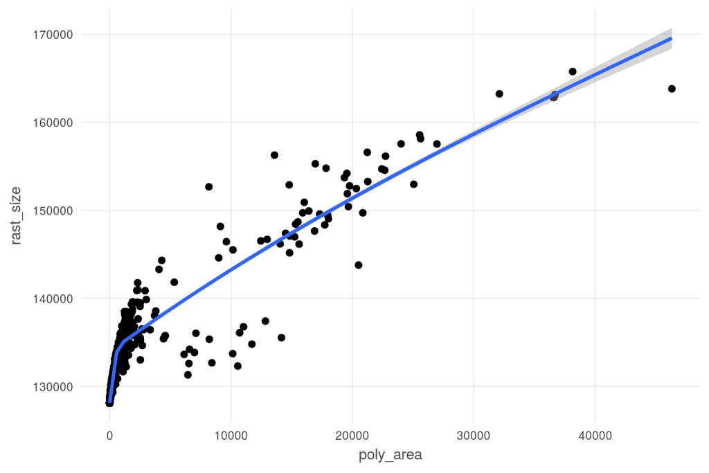

```r
poly_areas <- read_csv(file.path(dir_check, 'poly_areas.csv')) %>%
  mutate(group = str_replace_all(dbf_file, '\\.dbf$', '')) %>%
  group_by(iucn_sid, group, sciname) %>%
  summarize(poly_area = sum(shape_Area))
### note, this is for ALL species groups.
### Summing polys for spp with subpops; this may overestimate due to overlaps

### Get raster file sizes
rast_files <- list.files(file.path(dir_o_anx, 'rasters'),
                         pattern = '050deg.tif$',
                         full.names = TRUE)
rast_sizes <- data.frame(rast = basename(rast_files),
                         rast_size = file.size(rast_files)) %>%
  mutate(iucn_sid = str_extract(rast, '[0-9]+'),
         iucn_sid = as.integer(iucn_sid))

### Get extracted cell file sizes
extract_files <- list.files(file.path(dir_o_anx, 'rasters'),
                         pattern = '\\.csv$',
                         full.names = TRUE)
extract_sizes <- data.frame(csv = basename(extract_files),
                            csv_size = file.size(extract_files)) %>%
  mutate(group = str_replace_all(csv, '\\.csv$', ''))


area_vs_size <- poly_areas %>%
  inner_join(rast_sizes, by = 'iucn_sid') %>%
  full_join(extract_sizes, by = 'group') %>%
  filter(!is.na(csv)) ### these are dupes between MARINEFISH and other groups

ggplot(area_vs_size, aes(x = poly_area, y = rast_size)) +
  ggtheme_plot() +
  geom_point() +
  stat_smooth(formula = poly(rast_size, 2) ~ poly_area)
```

```r
# range(area_vs_size$rast_size)
# 128120 165757
```

Looks like the raster size is ~ square root of polygon size (more or less). This must be due to compression; otherwise the raster size should be proportional to polygon area (double the polygon area, double the number of included raster cells). But in any case, the range is very narrow: 128120 to 165757 bytes.

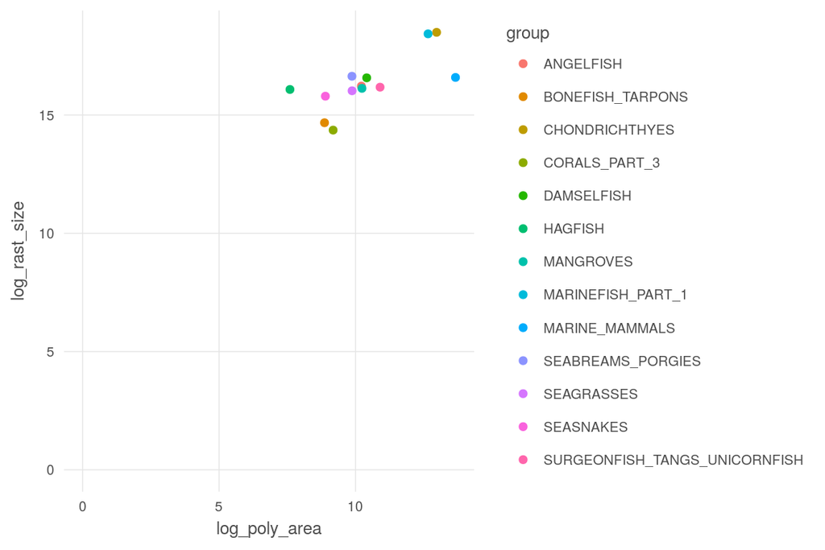

```r
tot_area_vs_size <- area_vs_size %>%
  group_by(group, csv_size) %>%
  summarize(tot_poly_area = sum(poly_area),
            tot_rast_size = sum(rast_size)) %>%
  mutate(log_poly_area = log(tot_poly_area),
         log_rast_size = log(tot_rast_size),
         log_csv_size = log(csv_size))

ggplot(tot_area_vs_size, aes(x = log_poly_area, y = log_rast_size, color = group)) +
  ggtheme_plot() +
  xlim(c(0, NA)) +
  ylim(c(0, NA)) +
  geom_point()
```

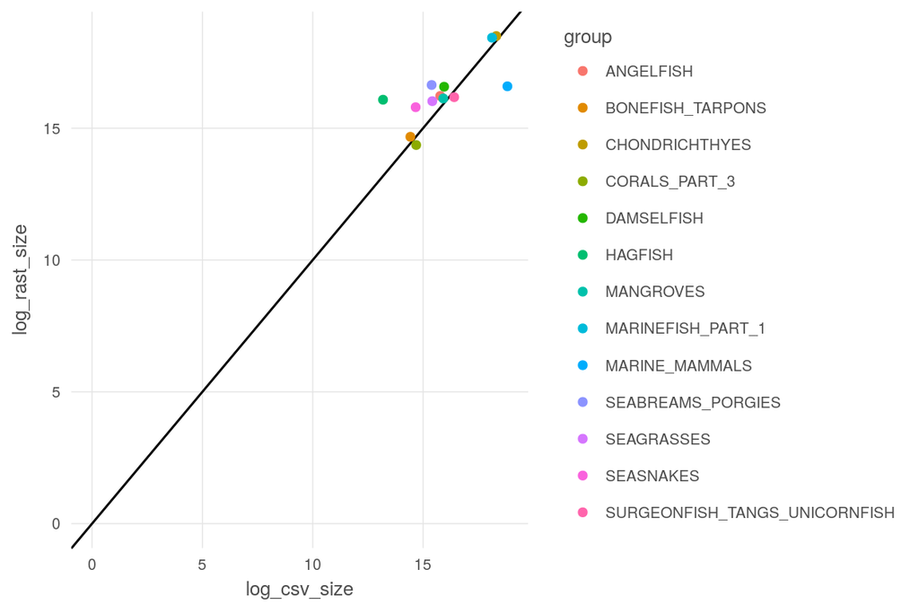

```r
ggplot(tot_area_vs_size, aes(x = log_csv_size, y = log_rast_size, color = group)) +
  ggtheme_plot() +
  xlim(c(0, NA)) +
  ylim(c(0, NA)) +
  geom_abline(intercept = 0, slope = 1) +
  geom_point()
```

The csv file size should be linear with total polygon size; as the polygon includes more cells, the csv gets longer; assuming no compression on the saved file.

Note that Marine Mammals seems to be an odd outlier, perhaps due to subpopulations; in the real data prep, these would be calculated separately, but they bear some checking.

## 2.2 Rasterize at quarter degree for comparison

```r
verbose <- FALSE

rast_base_halfdeg    <- raster(file.path(dir_git, 'spatial/loiczid_raster.tif'))
rast_base_quarterdeg <- raster(resolution = .25, ext = extent(rast_base_halfdeg))

spp_vs_time_df <- data.frame()

for(shp in shp_files) { ### shp <- shp_files[1]
  ptm_shp <- proc.time()
  if(verbose) cat('Processing', basename(shp), '...\n')
  shp_sf <- st_read(shp)
  if(verbose) cat('  Time to read shp:', (proc.time() - ptm_shp)[3], 's...\n')

  for(id in shp_sf$id_no) { ### id <- shp_sf$id_no[1]
    spp_shp <- shp_sf %>%
      filter(id_no == id)

    rast_file <- file.path(dir_o_anx, sprintf('rasters/iucn_sid_%s_025deg.tif', id))
    # if(verbose) cat('  Rasterizing', id, ':', spp_shp$binomial, 'to: ', basename(rast_file), '...\n')

    spp_rast <- fasterize::fasterize(spp_shp, rast_base_quarterdeg, field = 'presence', fun = 'min')


    raster::writeRaster(spp_rast, rast_file, overwrite = TRUE)
  }

  if(verbose) cat('  Elapsed time for', nrow(shp_sf), 'species:', (proc.time() - ptm_shp)[3], 's...\n')

  tmp_df <- data.frame('group' = basename(shp),
                       'n_spp' = nrow(shp_sf),
                       'time'  = (proc.time() - ptm_shp)[3])
  spp_vs_time_df <- spp_vs_time_df %>%
    bind_rows(tmp_df)

}

write_csv(spp_vs_time_df, file.path(dir_check, 'spp_time_to_rast_025deg.csv'))
```

## 2.3 Rasterize at tenth degree for comparison

```r
verbose <- FALSE

rast_base_halfdeg    <- raster(file.path(dir_git, 'spatial/loiczid_raster.tif'))
rast_base_tenthdeg <- raster(resolution = .10, ext = extent(rast_base_halfdeg))

spp_vs_time_df <- data.frame()

for(shp in shp_files) { ### shp <- shp_files[1]
  ptm_shp <- proc.time()
  if(verbose) cat('Processing', basename(shp), '...\n')
  shp_sf <- st_read(shp)
  if(verbose) cat('  Time to read shp:', (proc.time() - ptm_shp)[3], 's...\n')

  for(id in shp_sf$id_no) { ### id <- shp_sf$id_no[1]
    spp_shp <- shp_sf %>%
      filter(id_no == id)

    rast_file <- file.path(dir_o_anx, sprintf('rasters/iucn_sid_%s_010deg.tif', id))
    # if(verbose) cat('  Rasterizing', id, ':', spp_shp$binomial, 'to: ', basename(rast_file), '...\n')

    spp_rast <- fasterize::fasterize(spp_shp, rast_base_tenthdeg, field = 'presence', fun = 'min')


    raster::writeRaster(spp_rast, rast_file, overwrite = TRUE)
  }

  if(verbose) cat('  Elapsed time for', nrow(shp_sf), 'species:', (proc.time() - ptm_shp)[3], 's...\n')

  tmp_df <- data.frame('group' = basename(shp),
                       'n_spp' = nrow(shp_sf),
                       'time'  = (proc.time() - ptm_shp)[3])
  spp_vs_time_df <- spp_vs_time_df %>%
    bind_rows(tmp_df)

}

write_csv(spp_vs_time_df, file.path(dir_check, 'spp_time_to_rast_010deg.csv'))
```

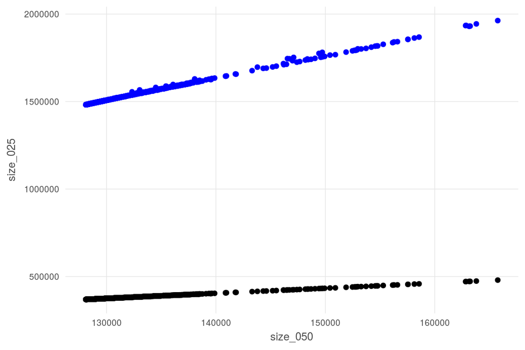

```r
rast_time_050 <- read_csv(file.path(dir_check, 'spp_time_to_rast_050deg.csv')) %>%
  rename(time_050 = time)
rast_time_025 <- read_csv(file.path(dir_check, 'spp_time_to_rast_025deg.csv')) %>%
  rename(time_025 = time)
rast_time_010 <- read_csv(file.path(dir_check, 'spp_time_to_rast_010deg.csv')) %>%
  rename(time_010 = time)

df <- full_join(rast_time_050, rast_time_025) %>%
  full_join(rast_time_010) %>%
  mutate(ratio_025 = time_025 / time_050,
         ratio_010 = time_010 / time_050)

### twice the resolution only takes twice as much time; 5 x resolution is about 10.5 x time.
# sum(df$time_025)
# 545.466    ### about 9 minutes for 2600 spp.  Less than an hour for 10k spp
# sum(df$time_010)
# 2621.743   ### about 43 minutes for 2600 spp.  About 3 hours for 10k spp


rasts_050 <- list.files(cache_dir, pattern = '050deg.tif$', full.names = TRUE)
rasts_025 <- list.files(cache_dir, pattern = '025deg.tif$', full.names = TRUE)
rasts_010 <- list.files(cache_dir, pattern = '010deg.tif$', full.names = TRUE)

df2 <- data.frame(rast_050 = basename(rasts_050),
                  size_050 = file.size(rasts_050),
                  rast_025 = basename(rasts_025),
                  size_025 = file.size(rasts_025),
                  rast_010 = basename(rasts_010),
                  size_010 = file.size(rasts_010)) %>%
  mutate(ratio_025 = size_025 / size_050,
         ratio_010 = size_010 / size_050)
### twice the resolution is about 2.9 times the size, not 4 times the size;
### five times resolution is about 11.6 times the size, not 25 times.

# sum(df2$size_025)
# 987989445    ### about 1 GB for 2600 spp... figure 4 gb total for 10k spp
# sum(df2$size_010)
# 3972184058   ### about 4 GB for 2600 spp... figure 16 gb total for 10k spp

ggplot(df2, aes(x = size_050, y = size_025)) +
  ggtheme_plot() +
  geom_point() +
  geom_point(aes(y = size_010), color = 'blue')
```

Based on these tests, it looks like rasterizing with `fasterize()` is FAR faster than `raster::extract()` method. At half-degree cells, the csv from `extract()` is similar in size to the total rasters from `fasterize()`; at finer resolutions the file size increases in a power around 1.5 (rather than quadratic as might be expected, prob due to compression).

Quarter degree cells give a resolution of about 27.5 kilometer square cells at the equator rather than 55 km for half-degree cells. Tenth-degree cells give a resolution of about 11.1 km square cells.